# 画像分類してみよう(仮)

## Handwritten or MachinePrinted

# ※かなり特殊な独自のデータセットを使っているのでまだ一般的なデータセットでは使えません。

このノートブックは画像分類器を作る例です。成果物として入力された文字画像が手書き文字か機械が印字した文字か判定する分類器を作成します。  
シンプルな例はMNISTなど素晴らしいものがたくさんあるのでここでは自作データセットを読み込んでみます。  
データセットは下記の感じで用意しています。(1クラス1ディレクトリ)

- 手書き文字：IAM databaseから取得した手書き文字画像から、word単位で切り出したもの
- 印字文字 ：上記wordの文字をフォントやサイズ・カラー(グレーだけど)をランダムに選択してPILで画像化したもの

### ※このノートブックはランタイムがTPUのColaboratoryで実行することを前提にしています。

### ※画像データセットはGoogle Driveに格納してある前提です。取得元は自由に書き換えてください。

### Google Drive のマウント

下記を実行すると認証を求められるので、認証すればGoogle Driveがマウントされる。  
その後データセットをコピーする。(wgetとかでパブリックなデータセットをとってきてもOK)

```python
from google.colab import drive
drive.mount('/content/drive')
```

```python
%%time
%cd /content
!mkdir -p work/debug
!mkdir input

%cd /content/input
# !cp /content/drive/'My Drive'/my_data/TextDetection/IAM/image_classfy.zip .
# !unzip -q image_classfy.zip
!cp /content/drive/'My Drive'/my_data/TextDetection/IAM/image_classfy_color.zip .
!unzip -q image_classfy_color.zip
```

```
/content
/content/input
CPU times: user 589 ms, sys: 102 ms, total: 691 ms
Wall time: 1min 57s
```

keras 等は入っているので特にインストール不要

```python
!pip install -U scikit-learn
```

```
    100% |████████████████████████████████| 5.4MB 4.3MB/s
  Found existing installation: scikit-learn 0.20.1
    Uninstalling scikit-learn-0.20.1:
      Successfully uninstalled scikit-learn-0.20.1
```

```python
import tensorflow as tf
from tensorflow.keras.applications import VGG16
from tensorflow.keras.layers import BatchNormalization, Activation, GlobalAveragePooling2D, Dense
from tensorflow.keras.models import Model
import tensorflow.keras.activations as activations
from tensorflow.keras.callbacks import History
from tensorflow.contrib.tpu.python.tpu import keras_support
import tensorflow.keras.backend as K

from keras.datasets import cifar10
from keras.utils import to_categorical
import numpy as np
import pickle, os

import pandas as pd
import random
from tqdm import tqdm
from sklearn.model_selection import train_test_split
from tensorflow.keras.callbacks import History, EarlyStopping, ReduceLROnPlateau, ModelCheckpoint
from keras.preprocessing import image
from keras.applications.imagenet_utils import preprocess_input
from sklearn.preprocessing import LabelEncoder
from sklearn.preprocessing import OneHotEncoder


IMAGE_DIR = '/content/input/cliped_images/'
HANDWRITTEN_DIR = '/content/input/cliped_images/'
PRINTED_DIR = '/content/input/created_images/'
KEEP_DATA_RATE = 0.4
IMAGE_SIZE = 48
CLASS_COUNT = 2
BATCH_SIZE = 1024
TRAIN_EPOCHS = 15
```

```python
from IPython.display import Image,display_jpeg
from PIL import Image as PIL_Image

def load_IAMcliped_data():

    file_list = os.listdir(IMAGE_DIR)

    df = pd.DataFrame(file_list,columns=['img'])
    tmp_df = df['img'].str.split('_', expand=True)
    tmp_df.columns = ['filename', 'id']
    df['filename'] = tmp_df['filename'] + '.jpg'
    file_list = df['filename'].unique().tolist()

    train_list = random.sample(file_list,k=int(len(file_list)*0.9))
    test_list = list(set(file_list) - set(train_list))

    #さすがに全データ流し込めなかったので一部Drop

    train_list = random.sample(train_list,k=int(len(train_list) * KEEP_DATA_RATE))
    test_list = random.sample(test_list,k=int(len(test_list) * KEEP_DATA_RATE))

    train_df_handwritten = HANDWRITTEN_DIR +  df[df['filename'].isin(train_list)]
    test_df_handwritten = HANDWRITTEN_DIR + df[df['filename'].isin(test_list)]
    train_df_handwritten['Id'] = 'handwritten'
    train_df_handwritten['y_train'] = 0
    test_df_handwritten['AnswerId'] = 'handwritten'

    train_df_printed = PRINTED_DIR +  df[df['filename'].isin(train_list)]
    test_df_printed = PRINTED_DIR + df[df['filename'].isin(test_list)]
    train_df_printed['Id'] = 'printed'
    train_df_printed['y_train'] = 1
    test_df_printed['AnswerId'] = 'printed'

    train_df = pd.concat([train_df_handwritten, train_df_printed]).reset_index(drop=True)
    test_df = pd.concat([test_df_handwritten, test_df_printed]).reset_index(drop=True)

    train_df['Image'] = train_df['img']
    train_df = train_df.drop(columns='img')
    test_df['Image'] = test_df['img']
    test_df = test_df.drop(columns='img')

    train_df = train_df.sample(frac=1).reset_index(drop=True)
    test_df = test_df.sample(frac=1).reset_index(drop=True)

    train_df.to_csv('/content/work/debug/train.csv',header=True,index=False)
    test_df.to_csv('/content/work/debug/test.csv',header=True,index=False)


    x_train = prepareImages(train_df, train_df.shape[0])
    x_train /= 255

    y_train = train_df['y_train'].astype('int').drop(columns=list(set(train_df.columns) - set(['y_train']))).values
    if len(y_train.shape) == 1:
      y_train = y_train.reshape(y_train.shape[0],1)

    img_train, ann_train, img_val, ann_val = train_test_split(x_train, y_train, train_size=0.9, random_state=1)
    return img_train, img_val, ann_train, ann_val

def remove_background_color(img, dropout_level=200):
    img_np = np.array(img)
    mask_white = img_np > dropout_level
    img_np[mask_white] = 255
    img = PIL_Image.fromarray(img_np)
    return img

def prepareImages(data, m):
    print("Preparing images")
    X_train = np.zeros((m, IMAGE_SIZE, IMAGE_SIZE, 3))
    count = 0

    for fig in tqdm(data['Image']):
        #load images into images of size 100x100x3
        img = image.load_img(fig, target_size=(IMAGE_SIZE, IMAGE_SIZE, 3))
        # 背景色で学習している可能性があるので背景色削除
        remove_background_color(img)
        x = image.img_to_array(img)
        x = preprocess_input(x)

        X_train[count] = x
        count += 1

    return X_train

def prepare_labels(y):
    values = np.array(y)
    label_encoder = LabelEncoder()
    integer_encoded = label_encoder.fit_transform(values)
    #print(integer_encoded)

    onehot_encoder = OneHotEncoder(sparse=False)
    integer_encoded = integer_encoded.reshape(len(integer_encoded), 1)
    onehot_encoded = onehot_encoder.fit_transform(integer_encoded)
    # print(onehot_encoded)

    y = onehot_encoded
    # print(y.shape)
    return y, label_encoder

def check_results(cpu_model):
    test_images = pd.read_csv('/content/work/debug/test.csv')
    test_images_sample = test_images.sample(15).reset_index(drop=True)

    test_sample = prepareImages(test_images_sample, test_images_sample.shape[0])
    test_sample = test_sample / 255
    predictions_sample = cpu_model.predict(test_sample, verbose=1)
    test_result_df_sample = pd.DataFrame(predictions_sample, columns=['handwritten', 'machine_printed'])
    test_result_df_sample['filename'] = test_images_sample['Image']
    for data in test_result_df_sample.values.tolist():
      print('*********************************************')
      display_jpeg(Image(data[2]))
      print(data[2])
      print('handwritten :' + str(data[0]) + '     ' + 'machine :' + str(data[1]))

    test = prepareImages(test_images, test_images.shape[0])
    test = test / 255
    predictions = cpu_model.predict(test, verbose=1)
    test_result_df = pd.DataFrame(predictions, columns=['handwritten', 'machine_printed'])
    test_result_df['filename'] = test_images['Image']
    precision, recall = eval_results(test_result_df)
    return precision, recall

def eval_results(df):
    cliped_df = df[df['filename'].str.contains('cliped_images')]
    created_df = df[df['filename'].str.contains('created_images')]
    TP_df = pd.concat([cliped_df[cliped_df['handwritten'] >= 0.5], created_df[created_df['machine_printed'] >= 0.5]])
    FN_df = pd.concat([cliped_df[cliped_df['handwritten'] < 0.5], created_df[created_df['machine_printed'] < 0.5]])
    FP_df = pd.concat([created_df[created_df['handwritten'] >= 0.5], cliped_df[cliped_df['machine_printed'] >= 0.5]])
    TN_df = pd.concat([created_df[created_df['handwritten'] < 0.5], cliped_df[cliped_df['machine_printed'] < 0.5]])
    precision = len(TP_df) / (len(TP_df) + len(FP_df))
    recall = len(TP_df) / (len(TP_df) + len(FN_df))
    return precision, recall
```

```python
def create_normal_model():
    model = VGG16(include_top=False, input_shape=(IMAGE_SIZE,IMAGE_SIZE,3), weights="imagenet")
    x = GlobalAveragePooling2D()(model.layers[-1].output)
    x = Dense(CLASS_COUNT, activation="softmax")(x)
    # あとでBatchNormを入れるため係数の固定はしない。初期値設定のみ転移学習とする
    return Model(model.inputs, x)

def create_batch_norm_model():
    model = create_normal_model()
    for i, layer in enumerate(model.layers):
        if i==0:
            input = layer.input
            x = input
        else:
            if "conv" in layer.name:
                layer.activation = activations.linear
                x = layer(x)
                x = BatchNormalization()(x)
                x = Activation("relu")(x)
            else:
                x = layer(x)

    bn_model = Model(input, x)
    return bn_model

def generator(X, y, batch_size):
    # 32->64に引き伸ばす操作でメモリ食い過ぎるので自分でジェネレーター書く
    while True:
        indices = np.arange(X.shape[0])
        np.random.shuffle(indices)
        if X.shape[1] < 48:
            for i in range(X.shape[0]//batch_size):
                current_indices = indices[i*batch_size:(i+1)*batch_size]
                X_batch = X[current_indices]
                # 2倍に引き伸ばす
                X_batch = X_batch.repeat(2, axis=1).repeat(2, axis=2)
                X_batch = X_batch / 255.0
                y_batch = to_categorical(y[current_indices], CLASS_COUNT)
                yield X_batch, y_batch
        else:
            for i in range(X.shape[0]//batch_size):
                current_indices = indices[i*batch_size:(i+1)*batch_size]
                X_batch = X[current_indices]
                y_batch = to_categorical(y[current_indices], CLASS_COUNT)
                yield X_batch, y_batch

def train(use_batch_norm):
#     (X_train, y_train), (X_test, y_test) = cifar10.load_data()
    X_train, y_train, X_test, y_test = load_IAMcliped_data()

    if use_batch_norm:
        model = create_batch_norm_model()
    else:
        model = create_normal_model()

    # 元の係数を壊さないように低めの学習率を使う
    model.compile(tf.train.RMSPropOptimizer(4e-6), "categorical_crossentropy", ["acc"])
    model.summary()

    tpu_grpc_url = "grpc://"+os.environ["COLAB_TPU_ADDR"]
    tpu_cluster_resolver = tf.contrib.cluster_resolver.TPUClusterResolver(tpu_grpc_url)
    strategy = keras_support.TPUDistributionStrategy(tpu_cluster_resolver)
    model = tf.contrib.tpu.keras_to_tpu_model(model, strategy=strategy)

#     hist = History()
    best_save_model_file = '/content/work/mymodel.h5'
    history = History()
    callbacks = [
                 EarlyStopping(monitor='val_loss',
                               patience=20,
                               verbose=1,
                               min_delta=0.00001,
                               mode='min'),
    #              ReduceLROnPlateau(monitor='val_loss',
    #                                factor=0.1,
    #                                patience=2,
    #                                verbose=1,
    #                                min_delta=0.0001,
    #                                mode='min'),
                 ModelCheckpoint(monitor='val_loss',save_weights_only=True,
                                 filepath=best_save_model_file,
                                 save_best_only=True,
                                 mode='min') ,
                 history,
                 ]


    batch_size = BATCH_SIZE

    model.fit_generator(generator(X_train, y_train, batch_size), steps_per_epoch=X_train.shape[0]//batch_size,
                        validation_data=generator(X_test, y_test, batch_size),
                        validation_steps=X_test.shape[0]//batch_size, callbacks=callbacks,#[hist],
                        epochs=TRAIN_EPOCHS)
    cpu_model = model.sync_to_cpu()
    json_string = cpu_model.to_json()
    open('/content/work/mymodel.json', 'w').write(json_string)
```

```python
K.clear_session()
use_batch_norm = True
```

```python
X_train, y_train, X_test, y_test = load_IAMcliped_data()
```

```
Preparing images
```

```python
from IPython.display import Image,display_jpeg
display_jpeg(Image(X_train[0]))
```

```python
pd.read_csv('/content/work/debug/train.csv').head(15)
```

|  | filename | Id | y_train | Image |
| --- | --- | --- | --- | --- |
| 0 | /content/input/cliped_images/n06-201.jpg | handwritten | 0 | /content/input/cliped_images/n06-201_00067.jpg |
| 1 | /content/input/cliped_images/b02-097.jpg | handwritten | 0 | /content/input/cliped_images/b02-097_00055.jpg |
| 2 | /content/input/cliped_images/l04-000.jpg | handwritten | 0 | /content/input/cliped_images/l04-000_00007.jpg |
| 3 | /content/input/cliped_images/g01-027.jpg | handwritten | 0 | /content/input/cliped_images/g01-027_00027.jpg |
| 4 | /content/input/cliped_images/r06-121.jpg | handwritten | 0 | /content/input/cliped_images/r06-121_00022.jpg |
| 5 | /content/input/created_images/k04-061.jpg | printed | 1 | /content/input/created_images/k04-061_00055.jpg |
| 6 | /content/input/created_images/g06-050c.jpg | printed | 1 | /content/input/created_images/g06-050c_00065.jpg |
| 7 | /content/input/created_images/a05-044.jpg | printed | 1 | /content/input/created_images/a05-044_00076.jpg |
| 8 | /content/input/cliped_images/h02-017.jpg | handwritten | 0 | /content/input/cliped_images/h02-017_00043.jpg |
| 9 | /content/input/created_images/a06-095.jpg | printed | 1 | /content/input/created_images/a06-095_00049.jpg |
| 10 | /content/input/created_images/d04-131.jpg | printed | 1 | /content/input/created_images/d04-131_00007.jpg |
| 11 | /content/input/created_images/h01-027.jpg | printed | 1 | /content/input/created_images/h01-027_00061.jpg |
| 12 | /content/input/cliped_images/h07-087.jpg | handwritten | 0 | /content/input/cliped_images/h07-087_00020.jpg |
| 13 | /content/input/cliped_images/f07-019a.jpg | handwritten | 0 | /content/input/cliped_images/f07-019a_00003.jpg |
| 14 | /content/input/created_images/m04-030.jpg | printed | 1 | /content/input/created_images/m04-030_00018.jpg |

```python
if use_batch_norm:
    model = create_batch_norm_model()
else:
    model = create_normal_model()

# 元の係数を壊さないように低めの学習率を使う
model.compile(tf.train.RMSPropOptimizer(4e-6), "categorical_crossentropy", ["acc"])
model.summary()

tpu_grpc_url = "grpc://"+os.environ["COLAB_TPU_ADDR"]
tpu_cluster_resolver = tf.contrib.cluster_resolver.TPUClusterResolver(tpu_grpc_url)
strategy = keras_support.TPUDistributionStrategy(tpu_cluster_resolver)
model = tf.contrib.tpu.keras_to_tpu_model(model, strategy=strategy)

best_save_model_file = '/content/work/mymodel.h5'
history = History()
callbacks = [
             EarlyStopping(monitor='val_loss',
                           patience=20,
                           verbose=1,
                           min_delta=0.00001,
                           mode='min'),
#              ReduceLROnPlateau(monitor='val_loss',
#                                factor=0.1,
#                                patience=2,
#                                verbose=1,
#                                min_delta=0.0001,
#                                mode='min'),
             ModelCheckpoint(monitor='val_loss',save_weights_only=True,
                             filepath=best_save_model_file,
                             save_best_only=True,
                             mode='min') ,
             history,
             ]


batch_size = BATCH_SIZE

model.fit_generator(generator(X_train, y_train, batch_size), steps_per_epoch=X_train.shape[0]//batch_size,
                    validation_data=generator(X_test, y_test, batch_size),
                    validation_steps=X_test.shape[0]//batch_size, callbacks=callbacks,#[hist],
                    epochs=TRAIN_EPOCHS)
cpu_model = model.sync_to_cpu()
json_string = cpu_model.to_json()
open('/content/work/mymodel.json', 'w').write(json_string)
```

```
Downloading data from https://github.com/fchollet/deep-learning-models/releases/download/v0.1/vgg16_weights_tf_dim_ordering_tf_kernels_notop.h5
_________________________________________________________________
Layer (type)                 Output Shape              Param #
=================================================================
input_1 (InputLayer)         (None, 48, 48, 3)         0
_________________________________________________________________
block1_conv1 (Conv2D)        (None, 48, 48, 64)        1792
_________________________________________________________________
batch_normalization (BatchNo (None, 48, 48, 64)        256
_________________________________________________________________
activation (Activation)      (None, 48, 48, 64)        0
_________________________________________________________________
block1_conv2 (Conv2D)        (None, 48, 48, 64)        36928
_________________________________________________________________
batch_normalization_1 (Batch (None, 48, 48, 64)        256
_________________________________________________________________
activation_1 (Activation)    (None, 48, 48, 64)        0
_________________________________________________________________
block1_pool (MaxPooling2D)   (None, 24, 24, 64)        0
_________________________________________________________________
block2_conv1 (Conv2D)        (None, 24, 24, 128)       73856
_________________________________________________________________
batch_normalization_2 (Batch (None, 24, 24, 128)       512
_________________________________________________________________
activation_2 (Activation)    (None, 24, 24, 128)       0
_________________________________________________________________
block2_conv2 (Conv2D)        (None, 24, 24, 128)       147584
_________________________________________________________________
batch_normalization_3 (Batch (None, 24, 24, 128)       512
_________________________________________________________________
activation_3 (Activation)    (None, 24, 24, 128)       0
_________________________________________________________________
block2_pool (MaxPooling2D)   (None, 12, 12, 128)       0
_________________________________________________________________
block3_conv1 (Conv2D)        (None, 12, 12, 256)       295168
_________________________________________________________________
batch_normalization_4 (Batch (None, 12, 12, 256)       1024
_________________________________________________________________
activation_4 (Activation)    (None, 12, 12, 256)       0
_________________________________________________________________
```

[output cut: 77 more lines]

[output not shown]

```
23119
```

```python
print(type(history.history))
print(history.history.keys())
```

```
<class 'dict'>
dict_keys(['val_loss', 'val_acc', 'loss', 'acc'])
```

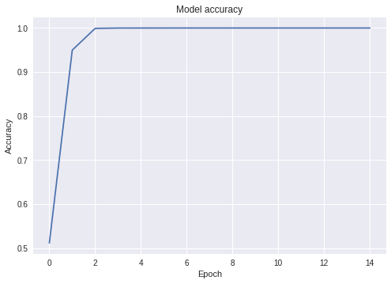

```python
import matplotlib.pyplot as plt
import matplotlib.image as mplimg
from matplotlib.pyplot import imshow

plt.plot(history.history['acc'])
plt.title('Model accuracy')
plt.ylabel('Accuracy')
plt.xlabel('Epoch')
plt.show()
```

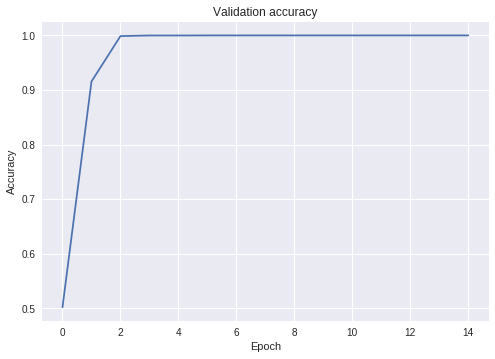

```python
plt.plot(history.history['val_acc'])
plt.title('Validation accuracy')
plt.ylabel('Accuracy')
plt.xlabel('Epoch')
plt.show()
```

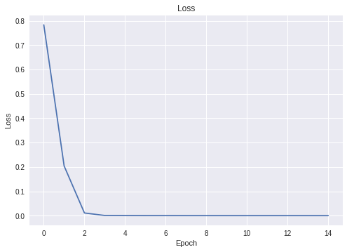

```python
plt.plot(history.history['loss'])
plt.title('Loss')
plt.ylabel('Loss')
plt.xlabel('Epoch')
plt.show()
```

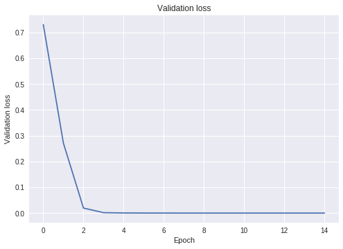

```python
plt.plot(history.history['val_loss'])
plt.title('Validation loss')
plt.ylabel('Validation loss')
plt.xlabel('Epoch')
plt.show()
```

```python
# file_list = os.listdir('/content/test')
# test_images = pd.DataFrame(file_list,columns=['Image'])
# test_images['Image'] = '/content/test/' + test_images['Image']
# test_images = test_images.sort_values('Image')
test_images = pd.read_csv('/content/work/debug/test.csv')
test_images = test_images.sample(15).reset_index(drop=True)
test = prepareImages(test_images, test_images.shape[0])
test = test /255
predictions = cpu_model.predict(test, verbose=1)
```

```
Preparing images
```

```python
test_result_df = pd.DataFrame(predictions, columns=['handwritten', 'machine_printed'])
# test_result_df['filename'] = test_images['Image']
test_result_df['filename'] = test_images['Image']
test_result_df
```

|  | handwritten | machine_printed | filename |
| --- | --- | --- | --- |
| 0 | 9.999996e-01 | 3.932832e-07 | /content/input/cliped_images/a01-000x_00038.jpg |
| 1 | 2.843535e-07 | 9.999998e-01 | /content/input/created_images/g04-039_00047.jpg |
| 2 | 2.244668e-07 | 9.999998e-01 | /content/input/created_images/n06-182_00017.jpg |
| 3 | 4.393728e-09 | 1.000000e+00 | /content/input/created_images/d06-072_00083.jpg |
| 4 | 9.999979e-01 | 2.096864e-06 | /content/input/cliped_images/g04-039_00027.jpg |
| 5 | 1.654410e-08 | 1.000000e+00 | /content/input/created_images/m02-066_00034.jpg |
| 6 | 2.023289e-09 | 1.000000e+00 | /content/input/created_images/n04-052_00046.jpg |
| 7 | 9.999999e-01 | 1.653958e-07 | /content/input/cliped_images/n06-182_00031.jpg |
| 8 | 9.999999e-01 | 1.080798e-07 | /content/input/cliped_images/j04-065_00073.jpg |
| 9 | 9.999999e-01 | 1.431698e-07 | /content/input/cliped_images/a04-092_00038.jpg |
| 10 | 9.999999e-01 | 1.112506e-07 | /content/input/cliped_images/p02-008_00048.jpg |
| 11 | 1.000000e+00 | 3.744876e-08 | /content/input/cliped_images/k04-068_00075.jpg |
| 12 | 9.999999e-01 | 9.065629e-08 | /content/input/cliped_images/a01-003u_00058.jpg |
| 13 | 9.999996e-01 | 3.353296e-07 | /content/input/cliped_images/a01-003u_00072.jpg |
| 14 | 1.000000e+00 | 5.780651e-08 | /content/input/cliped_images/b04-081_00035.jpg |

```python
precision, recall = eval_results(test_result_df)
print('precision : ' + str(precision))
print('recall : ' + str(recall))
```

```
precision : 1.0
recall : 1.0
```

```
/content/input/cliped_images/a01-000x_00038.jpg
handwritten :0.9999996423721313     machine :3.9328324419329874e-07
```

```
/content/input/created_images/g04-039_00047.jpg
handwritten :2.8435346166588715e-07     machine :0.9999997615814209
```

```
/content/input/created_images/n06-182_00017.jpg
handwritten :2.2446678826781863e-07     machine :0.9999997615814209
```

```
/content/input/created_images/d06-072_00083.jpg
handwritten :4.39372804805771e-09     machine :1.0
```

```
/content/input/cliped_images/g04-039_00027.jpg
handwritten :0.9999978542327881     machine :2.0968639091734076e-06
```

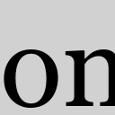

```
/content/input/created_images/m02-066_00034.jpg
handwritten :1.6544099423754233e-08     machine :1.0
```

```
/content/input/created_images/n04-052_00046.jpg
handwritten :2.023289313868304e-09     machine :1.0
```

```
/content/input/cliped_images/n06-182_00031.jpg
handwritten :0.9999998807907104     machine :1.6539580371954798e-07
```

```
/content/input/cliped_images/j04-065_00073.jpg
handwritten :0.9999998807907104     machine :1.0807981709604064e-07
```

```
/content/input/cliped_images/a04-092_00038.jpg
handwritten :0.9999998807907104     machine :1.431697995712966e-07
```

```
/content/input/cliped_images/p02-008_00048.jpg
handwritten :0.9999998807907104     machine :1.1125061405437009e-07
```

```
/content/input/cliped_images/k04-068_00075.jpg
handwritten :1.0     machine :3.744876408973141e-08
```

```
/content/input/cliped_images/a01-003u_00058.jpg
handwritten :0.9999998807907104     machine :9.065629313909085e-08
```

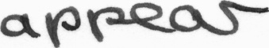

```
/content/input/cliped_images/a01-003u_00072.jpg
handwritten :0.9999996423721313     machine :3.3532958809701086e-07
```

```
/content/input/cliped_images/b04-081_00035.jpg
handwritten :1.0     machine :5.7806513353853006e-08
```

```python
from IPython.display import Image,display_jpeg
for data in test_result_df.values.tolist():
  print('*********************************************')
  display_jpeg(Image(data[2]))
  print(data[2])
  print('handwritten :' + str(data[0]) + '     ' + 'machine :' + str(data[1]))
```

```python
def find_good_epochs(train_epoch_list):
    result_list = []
    for epoch in train_epoch_list:
        K.clear_session()
        use_batch_norm = True
        if use_batch_norm:
            model = create_batch_norm_model()
        else:
            model = create_normal_model()

        # 元の係数を壊さないように低めの学習率を使う
        model.compile(tf.train.RMSPropOptimizer(4e-6), "binary_crossentropy", ["acc"])
        model.summary()

        tpu_grpc_url = "grpc://"+os.environ["COLAB_TPU_ADDR"]
        tpu_cluster_resolver = tf.contrib.cluster_resolver.TPUClusterResolver(tpu_grpc_url)
        strategy = keras_support.TPUDistributionStrategy(tpu_cluster_resolver)
        model = tf.contrib.tpu.keras_to_tpu_model(model, strategy=strategy)

        best_save_model_file = '/content/work/mymodel_maxEpoch' + str(epoch) + '.h5'
        history = History()
        callbacks = [
                     EarlyStopping(monitor='val_loss',
                                   patience=20,
                                   verbose=1,
                                   min_delta=0.00001,
                                   mode='min'),
        #              ReduceLROnPlateau(monitor='val_loss',
        #                                factor=0.1,
        #                                patience=2,
        #                                verbose=1,
        #                                min_delta=0.0001,
        #                                mode='min'),
                     ModelCheckpoint(monitor='val_loss',save_weights_only=True,
                                     filepath=best_save_model_file,
                                     save_best_only=True,
                                     mode='min') ,
                     history,
                     ]


        batch_size = BATCH_SIZE

        model.fit_generator(generator(X_train, y_train, batch_size), steps_per_epoch=X_train.shape[0]//batch_size,
                            validation_data=generator(X_test, y_test, batch_size),
                            validation_steps=X_test.shape[0]//batch_size, callbacks=callbacks,#[hist],
                            epochs=epoch)
        cpu_model = model.sync_to_cpu()
        precision, recall = check_results(cpu_model)
        print('precision : ' + str(precision))
        print('recall : ' + str(recall))
        result_list.append([best_save_model_file, precision])
    df = pd.DataFrame(result_list, columns=['weights', 'precision'])
    return df
```

```
_________________________________________________________________
Layer (type)                 Output Shape              Param #
=================================================================
input_1 (InputLayer)         (None, 48, 48, 3)         0
_________________________________________________________________
block1_conv1 (Conv2D)        (None, 48, 48, 64)        1792
_________________________________________________________________
batch_normalization (BatchNo (None, 48, 48, 64)        256
_________________________________________________________________
activation (Activation)      (None, 48, 48, 64)        0
_________________________________________________________________
block1_conv2 (Conv2D)        (None, 48, 48, 64)        36928
_________________________________________________________________
batch_normalization_1 (Batch (None, 48, 48, 64)        256
_________________________________________________________________
activation_1 (Activation)    (None, 48, 48, 64)        0
_________________________________________________________________
block1_pool (MaxPooling2D)   (None, 24, 24, 64)        0
_________________________________________________________________
block2_conv1 (Conv2D)        (None, 24, 24, 128)       73856
_________________________________________________________________
batch_normalization_2 (Batch (None, 24, 24, 128)       512
_________________________________________________________________
activation_2 (Activation)    (None, 24, 24, 128)       0
_________________________________________________________________
block2_conv2 (Conv2D)        (None, 24, 24, 128)       147584
_________________________________________________________________
batch_normalization_3 (Batch (None, 24, 24, 128)       512
_________________________________________________________________
activation_3 (Activation)    (None, 24, 24, 128)       0
_________________________________________________________________
block2_pool (MaxPooling2D)   (None, 12, 12, 128)       0
_________________________________________________________________
block3_conv1 (Conv2D)        (None, 12, 12, 256)       295168
_________________________________________________________________
batch_normalization_4 (Batch (None, 12, 12, 256)       1024
_________________________________________________________________
activation_4 (Activation)    (None, 12, 12, 256)       0
_________________________________________________________________
block3_conv2 (Conv2D)        (None, 12, 12, 256)       590080
```

[output cut: 76 more lines]

[output not shown]

```
Preparing images
```

```
/content/input/created_images/c03-000b_00047.jpg
handwritten :0.3813099265098572     machine :0.6186900734901428
```

```
/content/input/cliped_images/r06-053_00004.jpg
handwritten :0.6136569976806641     machine :0.38634300231933594
```

```
/content/input/created_images/n01-000_00052.jpg
handwritten :0.3535250425338745     machine :0.6464750170707703
```

```
/content/input/cliped_images/a01-003u_00076.jpg
handwritten :0.6963421702384949     machine :0.30365779995918274
```

```
/content/input/created_images/d06-072_00009.jpg
handwritten :0.5318758487701416     machine :0.4681241810321808
```

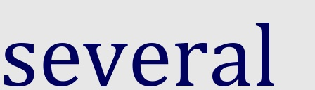

```
/content/input/created_images/r02-006_00016.jpg
handwritten :0.5430766940116882     machine :0.45692333579063416
```

```
/content/input/created_images/a02-008_00069.jpg
handwritten :0.4350200295448303     machine :0.5649799704551697
```

```
/content/input/created_images/a04-092_00035.jpg
handwritten :0.5628626346588135     machine :0.4371373653411865
```

```
/content/input/cliped_images/r06-053_00047.jpg
handwritten :0.37980517745018005     machine :0.6201947927474976
```

```
/content/input/cliped_images/c01-014_00034.jpg
handwritten :0.5683997869491577     machine :0.4316002130508423
```

```
/content/input/created_images/a02-008_00002.jpg
handwritten :0.5535374283790588     machine :0.4464625418186188
```

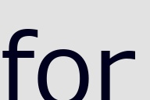

```
/content/input/created_images/r06-053_00012.jpg
handwritten :0.2346705049276352     machine :0.7653294801712036
```

```
/content/input/created_images/d06-072_00075.jpg
handwritten :0.45158663392066956     machine :0.5484133362770081
```

```
/content/input/created_images/c01-014_00012.jpg
handwritten :0.5455365180969238     machine :0.45446354150772095
```

```
/content/input/created_images/l07-131_00010.jpg
handwritten :0.42649003863334656     machine :0.5735099911689758
Preparing images
```

```
precision : 0.6442723753131405
recall : 0.6442723753131405
_________________________________________________________________
Layer (type)                 Output Shape              Param #
=================================================================
input_1 (InputLayer)         (None, 48, 48, 3)         0
_________________________________________________________________
block1_conv1 (Conv2D)        (None, 48, 48, 64)        1792
_________________________________________________________________
batch_normalization (BatchNo (None, 48, 48, 64)        256
_________________________________________________________________
activation (Activation)      (None, 48, 48, 64)        0
_________________________________________________________________
block1_conv2 (Conv2D)        (None, 48, 48, 64)        36928
_________________________________________________________________
batch_normalization_1 (Batch (None, 48, 48, 64)        256
_________________________________________________________________
activation_1 (Activation)    (None, 48, 48, 64)        0
_________________________________________________________________
block1_pool (MaxPooling2D)   (None, 24, 24, 64)        0
_________________________________________________________________
block2_conv1 (Conv2D)        (None, 24, 24, 128)       73856
_________________________________________________________________
batch_normalization_2 (Batch (None, 24, 24, 128)       512
_________________________________________________________________
activation_2 (Activation)    (None, 24, 24, 128)       0
_________________________________________________________________
block2_conv2 (Conv2D)        (None, 24, 24, 128)       147584
_________________________________________________________________
batch_normalization_3 (Batch (None, 24, 24, 128)       512
_________________________________________________________________
activation_3 (Activation)    (None, 24, 24, 128)       0
_________________________________________________________________
block2_pool (MaxPooling2D)   (None, 12, 12, 128)       0
_________________________________________________________________
block3_conv1 (Conv2D)        (None, 12, 12, 256)       295168
_________________________________________________________________
batch_normalization_4 (Batch (None, 12, 12, 256)       1024
_________________________________________________________________
activation_4 (Activation)    (None, 12, 12, 256)       0
```

[output cut: 78 more lines]

[output not shown]

```
Preparing images
```

```
/content/input/cliped_images/n01-000_00000.jpg
handwritten :0.6618885397911072     machine :0.3381114602088928
```

```
/content/input/created_images/g06-018g_00074.jpg
handwritten :0.4810396134853363     machine :0.5189603567123413
```

```
/content/input/created_images/g04-039_00052.jpg
handwritten :0.1751648634672165     machine :0.8248351216316223
```

```
/content/input/cliped_images/g06-018j_00041.jpg
handwritten :0.7258412837982178     machine :0.2741587162017822
```

```
/content/input/cliped_images/c03-000b_00054.jpg
handwritten :0.5434435606002808     machine :0.45655637979507446
```

```
/content/input/created_images/m02-102_00010.jpg
handwritten :0.12477581948041916     machine :0.8752241730690002
```

[figure not shown]

```
/content/input/created_images/r02-006_00017.jpg
handwritten :0.04485156014561653     machine :0.9551483988761902
```

```
/content/input/created_images/c01-014_00046.jpg
handwritten :0.0715780183672905     machine :0.9284219741821289
```

```
/content/input/created_images/c03-000f_00036.jpg
handwritten :0.09258583188056946     machine :0.9074141383171082
```

```
/content/input/cliped_images/k02-076_00001.jpg
handwritten :0.6569444537162781     machine :0.34305548667907715
```

```
/content/input/cliped_images/a01-000x_00022.jpg
handwritten :0.7693203687667847     machine :0.23067955672740936
```

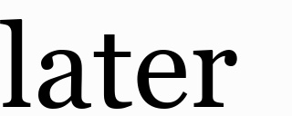

```
/content/input/created_images/g06-047p_00017.jpg
handwritten :0.03219161555171013     machine :0.9678084254264832
```

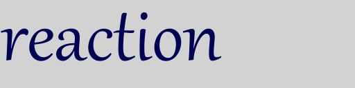

```
/content/input/created_images/e06-046_00023.jpg
handwritten :0.035115841776132584     machine :0.9648841023445129
```

```
/content/input/cliped_images/a04-092_00066.jpg
handwritten :0.6140540838241577     machine :0.3859459459781647
```

```
/content/input/created_images/h04-028_00002.jpg
handwritten :0.03535347059369087     machine :0.964646577835083
Preparing images
```

```
precision : 0.9396492826235482
recall : 0.9396492826235482
_________________________________________________________________
Layer (type)                 Output Shape              Param #
=================================================================
input_1 (InputLayer)         (None, 48, 48, 3)         0
_________________________________________________________________
block1_conv1 (Conv2D)        (None, 48, 48, 64)        1792
_________________________________________________________________
batch_normalization (BatchNo (None, 48, 48, 64)        256
_________________________________________________________________
activation (Activation)      (None, 48, 48, 64)        0
_________________________________________________________________
block1_conv2 (Conv2D)        (None, 48, 48, 64)        36928
_________________________________________________________________
batch_normalization_1 (Batch (None, 48, 48, 64)        256
_________________________________________________________________
activation_1 (Activation)    (None, 48, 48, 64)        0
_________________________________________________________________
block1_pool (MaxPooling2D)   (None, 24, 24, 64)        0
_________________________________________________________________
block2_conv1 (Conv2D)        (None, 24, 24, 128)       73856
_________________________________________________________________
batch_normalization_2 (Batch (None, 24, 24, 128)       512
_________________________________________________________________
activation_2 (Activation)    (None, 24, 24, 128)       0
_________________________________________________________________
block2_conv2 (Conv2D)        (None, 24, 24, 128)       147584
_________________________________________________________________
batch_normalization_3 (Batch (None, 24, 24, 128)       512
_________________________________________________________________
activation_3 (Activation)    (None, 24, 24, 128)       0
_________________________________________________________________
block2_pool (MaxPooling2D)   (None, 12, 12, 128)       0
_________________________________________________________________
block3_conv1 (Conv2D)        (None, 12, 12, 256)       295168
_________________________________________________________________
batch_normalization_4 (Batch (None, 12, 12, 256)       1024
_________________________________________________________________
activation_4 (Activation)    (None, 12, 12, 256)       0
```

[output cut: 78 more lines]

[output not shown]

```
Preparing images
```

```
/content/input/created_images/p02-008_00065.jpg
handwritten :0.0019968950655311346     machine :0.9980030655860901
```

```
/content/input/created_images/e06-046_00046.jpg
handwritten :0.006973275449126959     machine :0.9930267333984375
```

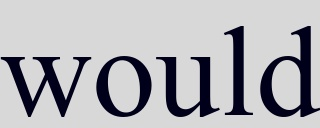

```
/content/input/created_images/b06-090_00003.jpg
handwritten :0.00022553997405339032     machine :0.9997745156288147
```

```
/content/input/created_images/c04-039_00024.jpg
handwritten :0.0012958032311871648     machine :0.998704195022583
```

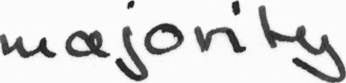

```
/content/input/cliped_images/a01-003u_00010.jpg
handwritten :0.9595986604690552     machine :0.04040136933326721
```

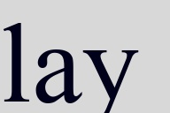

```
/content/input/created_images/b06-090_00009.jpg
handwritten :0.0002250394900329411     machine :0.9997749924659729
```

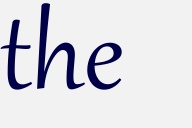

```
/content/input/created_images/a02-111_00045.jpg
handwritten :0.0006508543738164008     machine :0.9993491768836975
```

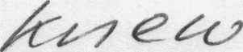

```
/content/input/cliped_images/p02-008_00066.jpg
handwritten :0.9909051656723022     machine :0.00909476075321436
```

```
/content/input/cliped_images/m04-100_00010.jpg
handwritten :0.9948968291282654     machine :0.005103124305605888
```

```
/content/input/created_images/n06-119_00017.jpg
handwritten :0.00028708032914437354     machine :0.9997128844261169
```

```
/content/input/cliped_images/n04-052_00021.jpg
handwritten :0.9974996447563171     machine :0.002500371541827917
```

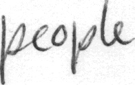

```
/content/input/cliped_images/b01-132_00022.jpg
handwritten :0.9975416660308838     machine :0.002458359347656369
```

```
/content/input/cliped_images/e06-046_00045.jpg
handwritten :0.7400908470153809     machine :0.25990912318229675
```

```
/content/input/created_images/g06-018j_00036.jpg
handwritten :0.00610968517139554     machine :0.9938902854919434
```

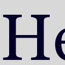

```
/content/input/created_images/a05-009_00010.jpg
handwritten :0.0006219240021891892     machine :0.9993780851364136
Preparing images
```

```
precision : 0.9998861307219312
recall : 0.9998861307219312
_________________________________________________________________
Layer (type)                 Output Shape              Param #
=================================================================
input_1 (InputLayer)         (None, 48, 48, 3)         0
_________________________________________________________________
block1_conv1 (Conv2D)        (None, 48, 48, 64)        1792
_________________________________________________________________
batch_normalization (BatchNo (None, 48, 48, 64)        256
_________________________________________________________________
activation (Activation)      (None, 48, 48, 64)        0
_________________________________________________________________
block1_conv2 (Conv2D)        (None, 48, 48, 64)        36928
_________________________________________________________________
batch_normalization_1 (Batch (None, 48, 48, 64)        256
_________________________________________________________________
activation_1 (Activation)    (None, 48, 48, 64)        0
_________________________________________________________________
block1_pool (MaxPooling2D)   (None, 24, 24, 64)        0
_________________________________________________________________
block2_conv1 (Conv2D)        (None, 24, 24, 128)       73856
_________________________________________________________________
batch_normalization_2 (Batch (None, 24, 24, 128)       512
_________________________________________________________________
activation_2 (Activation)    (None, 24, 24, 128)       0
_________________________________________________________________
block2_conv2 (Conv2D)        (None, 24, 24, 128)       147584
_________________________________________________________________
batch_normalization_3 (Batch (None, 24, 24, 128)       512
_________________________________________________________________
activation_3 (Activation)    (None, 24, 24, 128)       0
_________________________________________________________________
block2_pool (MaxPooling2D)   (None, 12, 12, 128)       0
_________________________________________________________________
block3_conv1 (Conv2D)        (None, 12, 12, 256)       295168
_________________________________________________________________
batch_normalization_4 (Batch (None, 12, 12, 256)       1024
_________________________________________________________________
activation_4 (Activation)    (None, 12, 12, 256)       0
```

[output cut: 78 more lines]

[output not shown]

```
Preparing images
```

```
/content/input/cliped_images/r02-006_00001.jpg
handwritten :0.9996812343597412     machine :0.0003187820839229971
```

[20 more figures not shown]

```
/content/input/cliped_images/e07-000_00016.jpg
handwritten :0.9999997615814209     machine :2.4263889031317376e-07
```

```
/content/input/cliped_images/a01-049x_00070.jpg
handwritten :0.9999997615814209     machine :2.103847265289005e-07
Preparing images
```

```
precision : 0.9998861307219312
recall : 0.9998861307219312
_________________________________________________________________
Layer (type)                 Output Shape              Param #
=================================================================
input_1 (InputLayer)         (None, 48, 48, 3)         0
_________________________________________________________________
block1_conv1 (Conv2D)        (None, 48, 48, 64)        1792
_________________________________________________________________
batch_normalization (BatchNo (None, 48, 48, 64)        256
_________________________________________________________________
activation (Activation)      (None, 48, 48, 64)        0
_________________________________________________________________
block1_conv2 (Conv2D)        (None, 48, 48, 64)        36928
_________________________________________________________________
batch_normalization_1 (Batch (None, 48, 48, 64)        256
_________________________________________________________________
activation_1 (Activation)    (None, 48, 48, 64)        0
_________________________________________________________________
block1_pool (MaxPooling2D)   (None, 24, 24, 64)        0
_________________________________________________________________
block2_conv1 (Conv2D)        (None, 24, 24, 128)       73856
_________________________________________________________________
batch_normalization_2 (Batch (None, 24, 24, 128)       512
_________________________________________________________________
activation_2 (Activation)    (None, 24, 24, 128)       0
_________________________________________________________________
block2_conv2 (Conv2D)        (None, 24, 24, 128)       147584
_________________________________________________________________
batch_normalization_3 (Batch (None, 24, 24, 128)       512
_________________________________________________________________
activation_3 (Activation)    (None, 24, 24, 128)       0
_________________________________________________________________
block2_pool (MaxPooling2D)   (None, 12, 12, 128)       0
_________________________________________________________________
block3_conv1 (Conv2D)        (None, 12, 12, 256)       295168
_________________________________________________________________
batch_normalization_4 (Batch (None, 12, 12, 256)       1024
_________________________________________________________________
activation_4 (Activation)    (None, 12, 12, 256)       0
```

[output cut: 77 more lines]

[output not shown]

```python
train_epoch_list = [1,2,3,4,5,6,7,8,9,10,11,12,13,14,15]
# train_epoch_list = [1,2,3]
result_df = find_good_epochs(train_epoch_list)
```

```python
result_df
```

|  | weights | precision |
| --- | --- | --- |
| 0 | /content/work/mymodel_maxEpoch1.h5 | 0.644272 |
| 1 | /content/work/mymodel_maxEpoch2.h5 | 0.939649 |
| 2 | /content/work/mymodel_maxEpoch3.h5 | 0.999886 |
| 3 | /content/work/mymodel_maxEpoch4.h5 | 0.999886 |
| 4 | /content/work/mymodel_maxEpoch5.h5 | 0.999886 |
| 5 | /content/work/mymodel_maxEpoch6.h5 | 1.000000 |
| 6 | /content/work/mymodel_maxEpoch7.h5 | 0.999886 |
| 7 | /content/work/mymodel_maxEpoch8.h5 | 1.000000 |
| 8 | /content/work/mymodel_maxEpoch9.h5 | 1.000000 |
| 9 | /content/work/mymodel_maxEpoch10.h5 | 1.000000 |
| 10 | /content/work/mymodel_maxEpoch11.h5 | 0.999886 |
| 11 | /content/work/mymodel_maxEpoch12.h5 | 1.000000 |
| 12 | /content/work/mymodel_maxEpoch13.h5 | 0.999886 |
| 13 | /content/work/mymodel_maxEpoch14.h5 | 0.999886 |
| 14 | /content/work/mymodel_maxEpoch15.h5 | 1.000000 |

```python
higher07 = result_df[result_df['precision'] > 0.7]
higher07.values.tolist()
```

```python
!mkdir /content/output
%cd /content/output
import shutil
for items in higher07.values.tolist():
    split_path = items[0].split('/')
    filename = split_path[len(split_path) - 1]
    shutil.copyfile(items[0], filename)
```

```python
!tar -zcvf better_models.tar.gz /content/output/*
!cp better_models.tar.gz /content/drive/'My Drive'/my_data/TextDetection/IAM/better_models`date "+%Y%m%d_%H%M%S"`.tar.gz
```

```python
X_test.shape
```

```python
y_test.shape
```

```python
y_test_df = pd.DataFrame(y_test, columns=['label'])
y_test_df.sample(15)
```

```python
y_test_df['label'].value_counts()
```